# Dobbler Theory

Luke Shaw

13 April 2019

A place for vaguely ordered thoughts on how to construct the dobble card image.

## Background and Background

I am almost exclusively using the functionality given by the [magick](https://cran.r-project.org/web/packages/magick/vignettes/intro.html) package.

When creating a dobble card you need your k images and the background, which is always a circle.

To define where to put an image on the circle, the coordinate of the top left corner of the image is defined in number of pixels from the top left of the image.

The base image can have as many pixels as you define, but for simplicity let’s fix it as a 1000 x 1000 grid. This should be enough, and is a nice number to work with.

```r
#the image is 1000*1000 pixels
n = 1000
bckgrnd <- magick::image_read("../figures/paint_circle.png")
```

```r
#define the matrix with TRUE/FALSE based on whether inside the circle
#circle has centre (n/2,n/2) and radius 19n/40
mat <- outer(1:1000,1:1000,
             FUN=function(x,y) (x-n/2)^2 + (y-n/2)^2 < (19*n/40)^2)
```

## Adding an image

```r
tiger <- magick::image_read_svg('http://jeroen.github.io/images/tiger.svg', width = 400)
tig_r <- tiger %>%
    image_background("red") %>%
    magick::image_scale(as.character(n/5)) #specify number of pixels in height
tig_r
```

[output not shown]

Now I am ready to add the image to the background, including a check whether I’m in the valid space, and an update to the matrix to add FALSE values in where I have added the image.

[figure not shown]

```r
#check if can add tig_r in a defined location
loc = c(n/2,n/2)

valid_loc <- function(mat,loc, height, width){
  #is it valid to add an image of dim width*height to
  #position loc (top left coord)
  if( ((loc[1]+height)>dim(mat)[1]) |
      ((loc[2]+width)>dim(mat)[2])){return(FALSE)}

  sub = mat[loc[1]:(loc[1] + width),loc[2]:(loc[2] + height)]
  if(dim(sub)[1] * dim(sub)[2] == sum(sub)){
    #ie all elements are TRUE
    return(TRUE)
  } else {return(FALSE)}
}

add_image <- function(base, img, loc, width=n/5){
  #adds the img to base$img with top-left coords loc, and updates base.
  #base is a list containing the image and the matrix of valid pixels.

  #TODO: find way of getitng image dimensions from img
  height = width
  #ideally wouldn't have to do this (doesn't belong in this fn)
  img = magick::image_scale(img, as.character(width))

  valid = valid_loc(base$mat, loc, height, width)
  if(valid==FALSE){warning("will overwrite some of the image here")}

  #add the new image and make matrix FALSE in those places
    base$img = base$img %>%
    magick::image_composite(img,
                  offset=paste0("+",loc[1],"+",loc[2]))
  base$mat[seq(loc[1],loc[1] + width),
           seq(loc[2],loc[2] + height)] = FALSE

  #update the base
  return(base)
}

base <- list(img = bckgrnd, mat = mat)
new <- add_image(base,tig_r, c(200,200))
new_bad <- add_image(base,tig_r, c(100,100))
new$img
```

[figure not shown]

```r
new_bad$img
```

## Creating a card through random location guessing

When creating the cards, we want different images of different sizes and orientations. The way I try and achieve this is by selecting a size and orientation, then trying some random location and seeing if it is a valid place

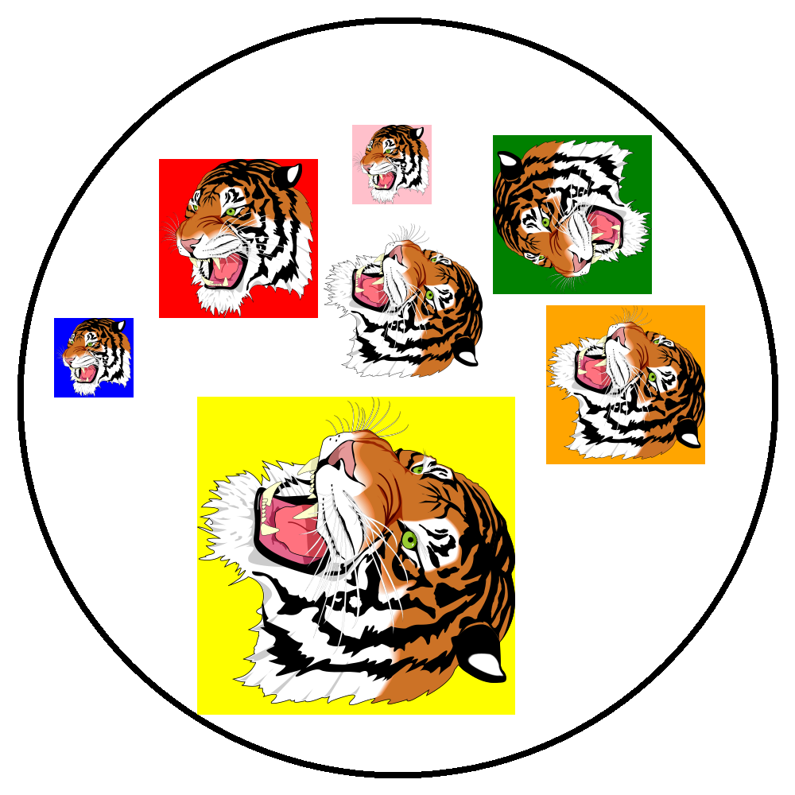

```r
main_pic = add_image(base,tig_r, c(200,200))

poss_heights = round(seq(n/10,n/2,length.out=5))
poss_rotates = c(0,90,180,270)
set.seed(1) #for consistent randomness on different runs

cols = c("orange","yellow","green","blue","pink","black","white")
for (num_images in 1:7){
  height = sample(poss_heights, size=1)
  rotate = sample(poss_rotates, size=1)
  img = tiger %>% image_background(cols[num_images]) %>% magick::image_rotate(rotate)
  a = FALSE
  b = 0
  #find a valid location
  while (a == FALSE){
    loc = round(n * runif(2)) #random location guess
    b = b + 1
    a = valid_loc(main_pic$mat,loc,height,height)
    if(b==1000){
      warning("can't find a location")
      a = "issue"}
  }
  if(a!="issue"){main_pic = add_image(main_pic, img, loc, height)}
}
main_pic$img
```